# Diferencia en diferencias en R

# Divorcio unilateral

Script de esta sesión

Los datos que usaremos son:

```r
wd <- divorce %>%
  filter(year>1964 & year<1996 & sex==2) %>%
  mutate(suicide_rate=suicide*1000000/(stpop*fshare),
         year=as.numeric(year))
```

La librería [*ExPanDaR*](https://joachim-gassen.github.io/ExPanDaR/) nos permite explorar datos de panel. Esta librería puede ser muy útil para sus proyectos.

Por ejemplo, para explorar valores faltantes:

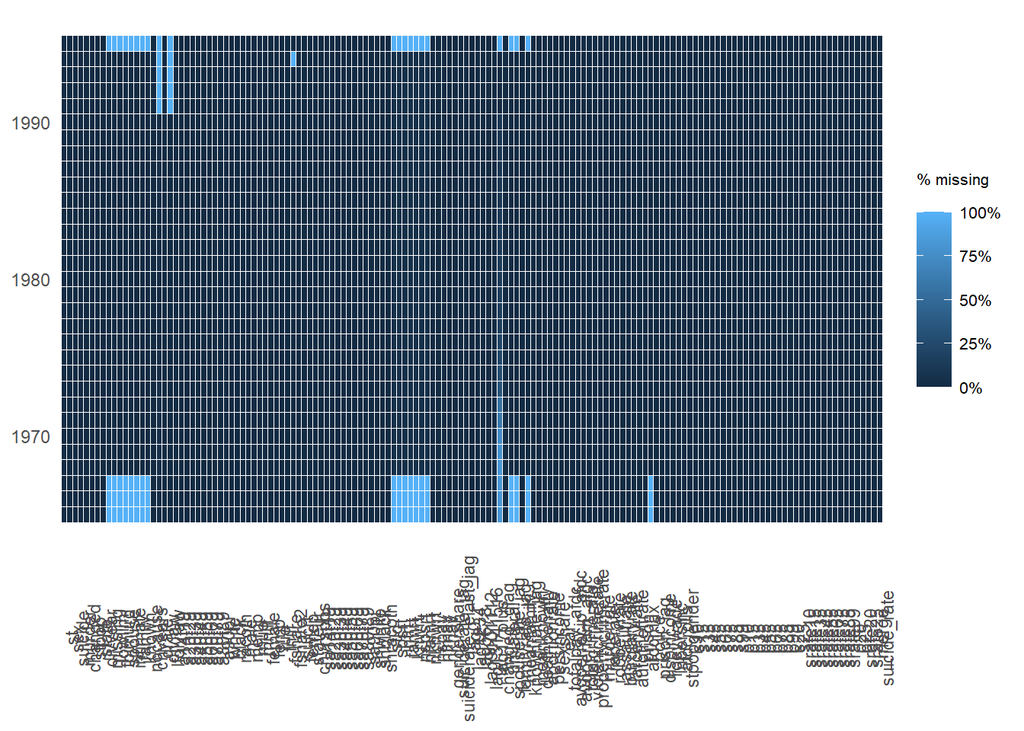

```r
prepare_missing_values_graph(wd, ts_id = "year")
```

Pueden generar también una aplicación interactiva. Vean qué pasa cuando ejecutan lo siguiente en RStudio:

```r
ExPanD(df = wd,
       ts_id="year",
       cs_id="st",
       title = "Wow, mis datos",
       abstract = "Datos tomados de Stevenson & Wolfers (2006)")
```

Es claro que estos datos corresponden a un caso en el que el tratamiento se asigna de forma *escalonada* a lo largo del tiempo.

# DID hasta antes de Goodman-Bacon

Como hemos visto, hasta hace no mucho se asumía que un estimador de efectos fijos (TWFE) operaba igual que en la versión 2x2 del diseño de DID, en cuyo caso, estimaríamos la siguiente ecuación:

$$\begin{aligned}
y_{st}=\alpha+\delta_{DID}UNILATERAL_{st}+\beta_{AK}
S_{AK}+\ldots+\beta_{WY}S_{WY}+\\
+\gamma_{1967}A_{1967}+\ldots+\gamma_{1989}A_{1989}+\varepsilon_{st}
\end{aligned}$$

Donde la dummy $UNILATERAL_{st}$ toma el valor de 1 en el estado $s$ y en el periodo $t$ cuando está en vigor una ley unilateral.

Entonces, si asumimos que todos los estados tienen tendencias paralelas, estimamos:

```r
wd <- divorce %>%
  filter(year>1964 & year<1996 & sex==2) %>%
  mutate(suicide_rate=suicide*1000000/(stpop*fshare),
         year=as.numeric(year))

#Asumiendo tendencias paralelas
modelo1 <- felm(suicide_rate ~ unilateral | factor(st) + factor(year),
                data = wd)

summary(modelo1)
```

```
##
## Call:
##    felm(formula = suicide_rate ~ unilateral | factor(st) + factor(year),      data = wd)
##
## Residuals:
##     Min      1Q  Median      3Q     Max
## -37.809  -6.126  -0.035   5.509  55.916
##
## Coefficients:
##            Estimate Std. Error t value Pr(>|t|)
## unilateral   -2.824      1.108   -2.55   0.0109 *
## ---
## Signif. codes:  0 '***' 0.001 '**' 0.01 '*' 0.05 '.' 0.1 ' ' 1
##
## Residual standard error: 10.8 on 1499 degrees of freedom
## Multiple R-squared(full model): 0.6908   Adjusted R-squared: 0.674
## Multiple R-squared(proj model): 0.004319   Adjusted R-squared: -0.04948
## F-statistic(full model):41.34 on 81 and 1499 DF, p-value: < 2.2e-16
## F-statistic(proj model): 6.502 on 1 and 1499 DF, p-value: 0.01088
```

Una manera de *relajar* el supuesto de tendencias paralelas era controlar por *tendencias específicas* al incorporar la interacción de los efectos fijos individuales con una tendencia, es decir, con la variable tiempo en niveles:

$$\begin{aligned}
y_{st}=\alpha+\delta_{DID}UNILATERAL_{st}+\beta_{AK}
S_{AK}+\ldots+\beta_{WY}S_{WY}+\\
+\gamma_{1967}A_{1967}+\ldots+\gamma_{1989}A_{1989}+\sum_k\theta_k(STATE_{ks}\times
t)+\varepsilon_{st}
\end{aligned}$$

```r
modelo2 <- felm(suicide_rate ~ unilateral | factor(st) + factor(year) + factor(st):year,
                data = wd)

summary(modelo2)
```

```
##
## Call:
##    felm(formula = suicide_rate ~ unilateral | factor(st) + factor(year) +      factor(st):year, data = wd)
##
## Residuals:
##     Min      1Q  Median      3Q     Max
## -35.193  -5.374  -0.096   4.585  49.639
##
## Coefficients:
##            Estimate Std. Error t value Pr(>|t|)
## unilateral    1.236      1.244   0.994    0.321
##
## Residual standard error: 9.457 on 1448 degrees of freedom
## Multiple R-squared(full model): 0.7709   Adjusted R-squared:  0.75
## Multiple R-squared(proj model): 0.0006814   Adjusted R-squared: -0.09042
## F-statistic(full model):36.92 on 132 and 1448 DF, p-value: < 2.2e-16
## F-statistic(proj model): 0.9874 on 1 and 1448 DF, p-value: 0.3206
## *** Standard errors may be too high due to more than 2 groups and exactDOF=FALSE
```

Sin importar la manera en que especificamos la regresión a estimar, no olvidemos que debemos estimar errores agrupados:

```r
modelo1a <- felm(suicide_rate ~ unilateral | factor(st) + factor(year) | 0 | st,
                data = wd)

summary(modelo1a)
```

```
##
## Call:
##    felm(formula = suicide_rate ~ unilateral | factor(st) + factor(year) |      0 | st, data = wd)
##
## Residuals:
##     Min      1Q  Median      3Q     Max
## -37.809  -6.126  -0.035   5.509  55.916
##
## Coefficients:
##            Estimate Cluster s.e. t value Pr(>|t|)
## unilateral   -2.824        2.274  -1.242     0.22
##
## Residual standard error: 10.8 on 1499 degrees of freedom
## Multiple R-squared(full model): 0.6908   Adjusted R-squared: 0.674
## Multiple R-squared(proj model): 0.004319   Adjusted R-squared: -0.04948
## F-statistic(full model, *iid*):41.34 on 81 and 1499 DF, p-value: < 2.2e-16
## F-statistic(proj model): 1.543 on 1 and 50 DF, p-value: 0.22
```

```r
modelo2a <- felm(suicide_rate ~ unilateral | factor(st) + factor(year) + factor(st):year | 0 | st,
                data = wd)

summary(modelo2a)
```

```
##
## Call:
##    felm(formula = suicide_rate ~ unilateral | factor(st) + factor(year) +      factor(st):year | 0 | st, data = wd)
##
## Residuals:
##     Min      1Q  Median      3Q     Max
## -35.193  -5.374  -0.096   4.585  49.639
##
## Coefficients:
##            Estimate Cluster s.e. t value Pr(>|t|)
## unilateral    1.236        2.193   0.564    0.575
##
## Residual standard error: 9.457 on 1448 degrees of freedom
## Multiple R-squared(full model): 0.7709   Adjusted R-squared:  0.75
## Multiple R-squared(proj model): 0.0006814   Adjusted R-squared: -0.09042
## F-statistic(full model, *iid*):36.92 on 132 and 1448 DF, p-value: < 2.2e-16
## F-statistic(proj model): 0.3179 on 1 and 50 DF, p-value: 0.5754
## *** Standard errors may be too high due to more than 2 groups and exactDOF=FALSE
```

# Descomposición de Goodman-Bacon

La descomposición de Goodman-Bacon (2021)[^2] parte el efecto estimado con el estimador de panel en una suma ponderada de todas las posibles comparaciones 2x2 en nuestro diseño. Aquí, recuperamos dichas ponderaciones:

```r
df_bacon <- bacon(suicide_rate ~ unilateral,
                  data = wd,
                  id_var = "st",
                  time_var = "year")
```

```
##                       type  weight  avg_est
## 1 Earlier vs Later Treated 0.10544  1.70904
## 2  Later vs Always Treated 0.39872 -6.72231
## 3 Later vs Earlier Treated 0.27432  3.31462
## 4     Treated vs Untreated 0.22151 -5.56686
```

```r
coef_bacon <- sum(df_bacon$estimate * df_bacon$weight)
print(paste("Weighted sum of decomposition =", round(coef_bacon, 4)))
```

```
## [1] "Weighted sum of decomposition = -2.824"
```

```r
fit_tw <- lm(suicide_rate ~ unilateral + factor(st) + factor(year),
             data = wd)
print(paste("Two-way FE estimate =", round(fit_tw$coefficients[2], 4)))
```

```
## [1] "Two-way FE estimate = -2.824"
```

Con los pesos estimados, podemos replicar la figura 6 en Goodman-Bacon (2021):

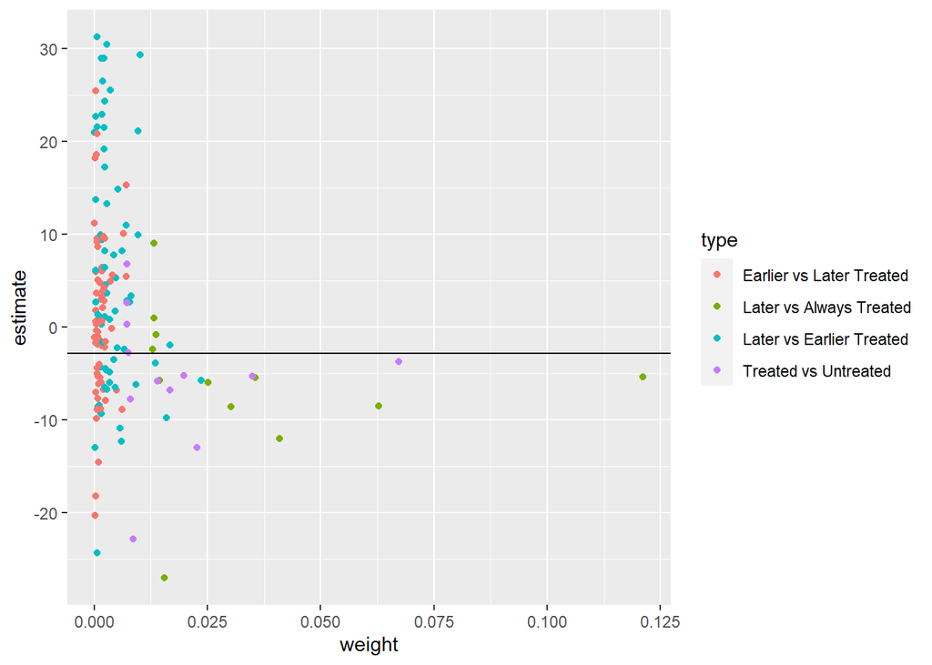

```r
df_bacon %>%
  ggplot(aes(x=weight,
             y=estimate,
             color=type)) +
  geom_point() +
  geom_hline(yintercept = round(fit_tw$coefficients[2], 4))
```

# Estimador de Sun y Abraham (2020)

A partir de la descomposición de Goodman-Bacon, la literatura de DID se ha encargado de desarrollar estimadores que tengan propiedades deseables en el contexto de tratamientos escalonados y heterogéneos. Esta literatura es amplia y muy viva.

Una de estas propuestas es el estimador de Sun y Abraham (2020)[^3].

Definimos *periodos_desde_t* como el número de periodos desde el tratamiento (negativo antes del tratamiento):

```r
wd <- wd %>%
  mutate(periodos_desde_t = year-divyear)
```

La función *sunab* hace el trabajo:

```r
modeloSA <-  feols(suicide_rate ~ sunab(divyear, periodos_desde_t) | st + year,
                   data = wd,
                   vcov = ~st)

summary(modeloSA)
```

```
## OLS estimation, Dep. Var.: suicide_rate
## Observations: 1,580
## Fixed-effects: st: 51,  year: 31
## Standard-errors: Clustered (st)
##                         Estimate Std. Error   t value   Pr(>|t|)
## periodos_desde_t::-20 -10.663445    4.72185 -2.258320 2.8321e-02 *
## periodos_desde_t::-19  13.857885    4.85840  2.852355 6.2945e-03 **
## periodos_desde_t::-18   5.677232    4.26677  1.330569 1.8937e-01
## periodos_desde_t::-17   4.097420    3.37557  1.213847 2.3051e-01
## periodos_desde_t::-16   8.115661    3.29142  2.465701 1.7150e-02 *
## periodos_desde_t::-15  11.241617    3.14695  3.572225 7.9432e-04 ***
## periodos_desde_t::-14  12.213173    3.26990  3.735035 4.8191e-04 ***
## periodos_desde_t::-13  11.971642    2.49972  4.789198 1.5328e-05 ***
## periodos_desde_t::-12  -0.078732   15.26070 -0.005159 9.9590e-01
## periodos_desde_t::-11  -6.380758    9.68603 -0.658759 5.1307e-01
## periodos_desde_t::-10   1.247085    8.79044  0.141868 8.8775e-01
## periodos_desde_t::-9   -4.479254    4.68837 -0.955396 3.4397e-01
## periodos_desde_t::-8   -2.326133    5.26142 -0.442111 6.6032e-01
## periodos_desde_t::-7   -2.617671    4.85507 -0.539162 5.9217e-01
## periodos_desde_t::-6   -1.127235    3.81705 -0.295316 7.6898e-01
## periodos_desde_t::-5   -4.359393    3.33702 -1.306371 1.9740e-01
## periodos_desde_t::-4   -1.411851    2.97471 -0.474618 6.3713e-01
## periodos_desde_t::-3   -2.089115    3.16265 -0.660558 5.1193e-01
## periodos_desde_t::-2   -2.065683    2.73175 -0.756175 4.5309e-01
## periodos_desde_t::0    -2.506276    2.80925 -0.892150 3.7659e-01
## periodos_desde_t::1    -2.716946    2.92421 -0.929120 3.5729e-01
## periodos_desde_t::2    -5.617731    4.29786 -1.307098 1.9716e-01
## periodos_desde_t::3    -4.028384    3.00834 -1.339071 1.8660e-01
## periodos_desde_t::4    -5.912147    3.28913 -1.797483 7.8299e-02 .
## periodos_desde_t::5    -6.155564    2.77573 -2.217635 3.1153e-02 *
## periodos_desde_t::6    -6.568141    3.79553 -1.730494 8.9710e-02 .
## periodos_desde_t::7    -9.007719    3.77607 -2.385473 2.0887e-02 *
## periodos_desde_t::8   -10.362469    3.34905 -3.094155 3.2282e-03 **
## periodos_desde_t::9    -7.645259    3.38859 -2.256174 2.8464e-02 *
## periodos_desde_t::10  -10.610922    3.76772 -2.816274 6.9360e-03 **
## periodos_desde_t::11  -11.812141    3.77425 -3.129665 2.9195e-03 **
## periodos_desde_t::12   -8.859620    4.25257 -2.083359 4.2351e-02 *
## periodos_desde_t::13  -10.219571    4.11278 -2.484835 1.6353e-02 *
## periodos_desde_t::14  -10.492735    4.36057 -2.406277 1.9854e-02 *
## periodos_desde_t::15  -12.042415    4.63073 -2.600544 1.2207e-02 *
## periodos_desde_t::16   -9.117511    4.68542 -1.945933 5.7294e-02 .
## periodos_desde_t::17  -10.551906    5.02320 -2.100635 4.0737e-02 *
## periodos_desde_t::18  -13.095367    4.42974 -2.956236 4.7421e-03 **
## periodos_desde_t::19  -12.765757    3.78465 -3.373033 1.4425e-03 **
## periodos_desde_t::20  -11.932802    4.63717 -2.573295 1.3087e-02 *
## periodos_desde_t::21  -13.768065    4.56510 -3.015939 4.0196e-03 **
## periodos_desde_t::22  -14.391258    4.44866 -3.234968 2.1592e-03 **
## periodos_desde_t::23  -16.349332    6.63290 -2.464885 1.7184e-02 *
## periodos_desde_t::24  -19.418434    6.61372 -2.936085 5.0121e-03 **
## periodos_desde_t::25  -28.753388   13.76818 -2.088395 4.1875e-02 *
## periodos_desde_t::26   -8.424320   13.84992 -0.608258 5.4577e-01
## ---
## Signif. codes:  0 '***' 0.001 '**' 0.01 '*' 0.05 '.' 0.1 ' ' 1
## RMSE: 9.14789     Adj. R2: 0.67575
##                 Within R2: 0.246697
```

Tenemos una colección de coeficientes estimados con su correspondiente intervalo de confianza que podemos graficar usando *iplot*:

[output not shown]

Le podemos dar el formato que queramos:

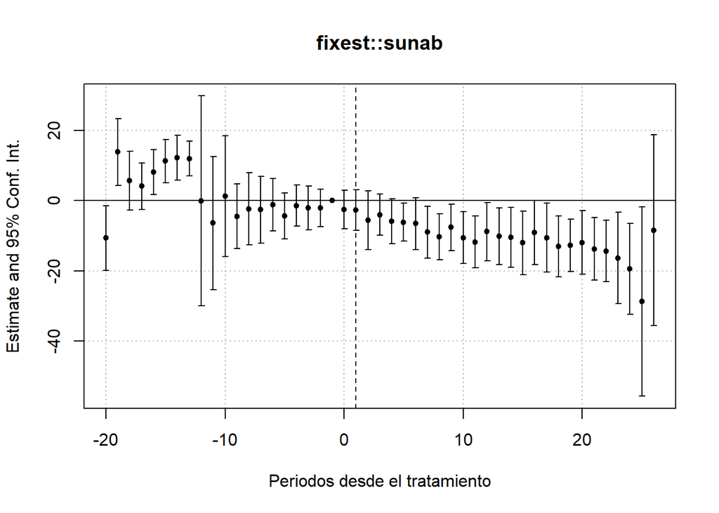

```r
modeloSA %>%
  iplot(main = "fixest::sunab",
    xlab = "Periodos desde el tratamiento",
    ref.line = 1)
```

Otro estimador que ha recibido atención recientemente es el propuesto por Callaway & Sant’Anna (2021), que utiliza un *propensity score* para pesar comparaciones 2x2.

[^1]: Bargaining in the shadow of the law: Divorce laws and family distress. *The Quarterly Journal of Economics*, 121(1), 267-288.
[^2]: Goodman-Bacon, A. (2021). Difference-in-differences with variation in treatment timing. *Journal of Econometrics*, 225(2), 254-277.
[^3]: Sun, L., & Abraham, S. (2021). Estimating dynamic treatment effects in event studies with heterogeneous treatment effects. *Journal of Econometrics*, 225(2), 175-199.